# Introduction to metadeconfoundR

Till Birkner, Sofia Kirke Forslund-Startceva

2026-07-23

# Introduction

When analyzing multi omics datasets, the search for features that could serve as biomarkers is an important aspect. Because these biomarkers might be used in clinical settings for disease diagnosis etc., it is extremely important to minimize false positives. One possible error source are confounding variables: The biomarker is not directly linked to the disease but influenced by a third (confounding) variable, that in turn is linked to the disease.

The R package `metadeconfoundR` was developed to address this issue. It first uses univariate statistics to find associations between omics features and disease status or metadata. Using nested linear model comparison post hoc testing, those associations are checked for confounding effects from other covariates/metadata and a status label is returned. The tool is able to handle large scale multi-omics datasets in a reasonable time, by parallel processing suitable for high-performance computing clusters. In addition, results can be summarized by a range of plotting functions.

## MetaDeconfound()

The main (`metadeconfoundR::MetaDeconfound()`) analysis is a two step process:

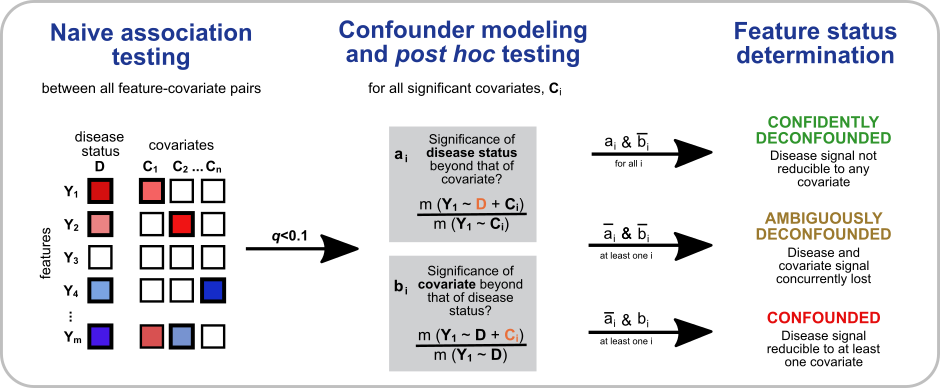

Figure 1: metadeconfoundR pipeline overview.

First, significant associations between single omics features (like gut microbial OTUs) and metadata (like disease status, drug administration, BMI) are identified. Based on the data type of the respective metadata, either `wilcox.test()` (for binary), `cor.test()` (for continuous numerical) or `kruskal.test()` (for neither numerical nor binary) is used. All three tests are rank-based to minimize assumptions about data distribution (*Fig. 1*, left). In addition to collecting p-values for all computed tests, effect size is measured as Cliff’s Delta and Spearman’s Rho for binary and continuous data, respectively. Since there is no suitable effect size metric for categorical data with more than 2 levels, no value is reported here. It is recommended to introduce binary pseudo-variables for each level of the categorical metadata to partially circumvent this drawback.

In the second step, all hits are checked for confounding effects and a status is reported for each feature-metadata combination (*Fig. 1*, center and right; *Fig. 2*). A “hit” here is defined as a feature-metadata association with small enough fdr-corrected p-value and big enough effect size reported from the first, naive part of the pipeline. Thresholds for both parameters can be set via `QCutoff` and `DCutoff` when starting the analysis. Since confounding of signal can only happen with more than one metadata variable associated to a certain feature, all features with only one significant metadata association are trivially deconfounded and get status “No Covariates (OK_nc)”.

The actual confounder detection is done by performing a set of two likelihood ratio tests (LRTs) of nested linear models. For each possible combination of a feature and two of its associated metavariables, three models are fitted to the rank-transformed feature:

- lm(rank(feature) ~ covariate1 + covariate2), the full model
- lm(rank(feature) ~ covariate1), a model with only covariate1 as independent variable
- lm(rank(feature) ~ covariate2), a model with only covariate2 as independent variable.

LRTs reveal whether inclusion of covariate1 and/or covariate2 significantly improves the performance of the model. Random and/or fixed effects can be added to all models by the user. These additional effects will, however, not be considered in the first naive association testing step of the pipeline.

Importantly, `metadeconfoundR` will always **rank-transform the features** during analysis.

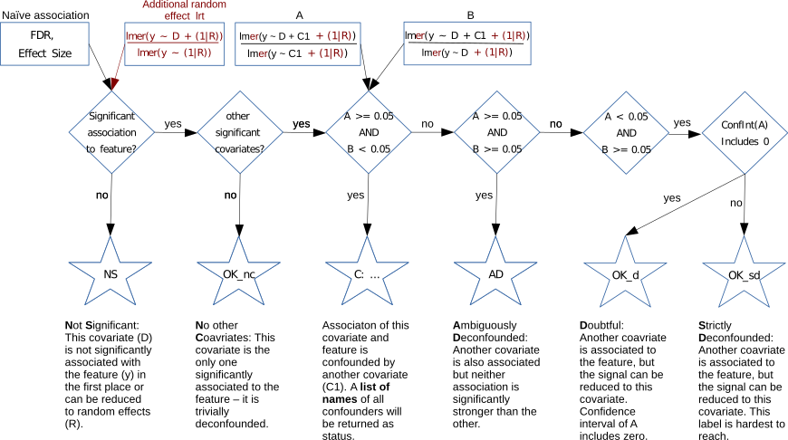

Figure 2: detailed status labelling decision tree.

# Quick start

```r
# CRAN
install.packages("metadeconfoundR")
# github stable version
devtools::install_github("TillBirkner/metadeconfoundR")
# github developmental version
devtools::install_github("TillBirkner/metadeconfoundR@develop")
library(metadeconfoundR)
```

# MetaDeconfound()

## Input

Minimal input consists of two data.frames for feature data (*Tab. 1*) and metadata (*Tab. 2*), respectively. Both data.frames must have one row per sample (sample names as rownames) with matching order of sampleIDs and one feature/meta-variable per column. The first column of the metadata data.frame must be binary (i.e be numeric and consist of only 0/1 entries.) Usually this is the control/case variable, but any other binary meta-variable will work as well.

Table 1: feature input format example

|  | MS0001 | MS0006 | MS0007 | MS0008 | MS0012 |
| --- | --- | --- | --- | --- | --- |
| BGI003A | 0 | 42.0 | 4.0 | 153.0 | 126.0 |
| BGI089A | 0 | 155.5 | 34.5 | 360.5 | 116.5 |
| DLF001 | 3 | 67.0 | 6.0 | 443.0 | 40.0 |
| DLF002 | 1 | 58.0 | 18.0 | 175.0 | 181.5 |
| DLF003 | 45 | 43.0 | 0.0 | 66.0 | 74.0 |
| DLF004 | 0 | 41.0 | 1.0 | 206.0 | 37.0 |

Table 2: metadata input format example

|  | Status | Dataset | Metformin | continuous_dummy | altered_dummy |
| --- | --- | --- | --- | --- | --- |
| BGI003A | 0 | CHN | 0 | 0.0617863 | 0.0617863 |
| BGI089A | 0 | CHN | 0 | 0.2059746 | 0.2059746 |
| DLF001 | 1 | CHN | 0 | 0.1765568 | 0.1765568 |
| DLF002 | 1 | CHN | 0 | 0.6870228 | 0.6870228 |
| DLF003 | 1 | CHN | 1 | 0.3841037 | 0.3841037 |
| DLF004 | 1 | CHN | 0 | 0.7698414 | 0.7698414 |

`MetaDeconfound()` has built-in quality checks for formatting of the input data but it is best to check proper formatting beforehand.

Ensure that colnames and rownames do not contain any problematic characters by e.g running them through `make.names()` and check for same order of rows in both input data.frames.

```r
data(reduced_feature)
data(metaMatMetformin)

# check correct ordering
all(rownames(metaMatMetformin) == rownames(reduced_feature))
```

```
#> [1] TRUE
```

```r
all(order(rownames(metaMatMetformin)) == order(rownames(reduced_feature)))
```

```
#> [1] TRUE
```

```r
example_output <- MetaDeconfound(
  featureMat = reduced_feature,
  metaMat = metaMatMetformin,
  returnLong = TRUE,
  logLevel = "ERROR"
)
```

```r
RandDataset_output <- MetaDeconfound(
  featureMat = reduced_feature,
  metaMat = metaMatMetformin,
  randomVar = c("Dataset"),
  returnLong = TRUE,
  logLevel = "ERROR"
)
```

For a full list of input parameters please refer to the help page.

### Input data requirements

When using default mode in `MetaDeconfound()`, feature values are internally rank-transformed. Consequently, any monotonic preprocessing or transformation that preserves the ranking order (e.g., log transformation) will not affect the results. Only preprocessing steps that intentionally modify the ordering of observations (e.g. rarefaction or TSS normalization of microbiome count data) need to be applied before running `MetaDeconfound()`, as the preprocessing or normalization steps are not performed within this framework.

The default rank-based workflow remains the standard analysis mode because it provides a robust, distribution-agnostic framework that performs consistently across sparse, zero-inflated, and heterogeneous datasets without requiring omics-specific modelling assumptions.

However, preprocessing approaches that intentionally encode biologically relevant information in quantitative distances between observations (e.g., CLR transformation) may be better suited to analysis modes that operate directly on the transformed values. In this special case, the `clr_mode` can be activated to switch the analysis from using non-parametric/rank-based approaches to a parametric equivalent. Note that no ranking, transformation, or normalization is performed within metadeconfoundR in this mode. Therefore, users should supply data for which parametric linear models are considered appropriate. A full comparison of the methodologies employed for the different analysis modes can be found in *Tab. 3* below. Unless the user is confident that the requirements of the parametric methods in `clr_mode` are met, we advise using the more robust default mode.

**Table 3: Comparison of tests and models used in different MetaDeconfound() modes.**

| mode |  | default | rawCounts | logistic | clr_mode |
| --- | --- | --- | --- | --- | --- |
| **feature data type** |  | everything not like the other modes | raw count data | binary data (presence/absence) | CLR-like data |
| **internal feature transform. for naive tests** |  | none | TSS transformation | none | none |
| **continuous metadata** | **test** | spearman cor.test | spearman cor.test | glm(family = “binomial”) + lrtest() | pearson cor.test |
|  | **effect size** | Spearman’s Rho | Spearman’s Rho | Cliff’s Delta | Pearson’s r |
| **binary metadata** | **test** | wilcox.test | wilcox.test | glm(family = “binomial”) + lrtest() | t.test |
|  | **effect size** | Cliff’s Delta | Cliff’s Delta | Phi coefficient | Pearson’s r |
| **categorical metadata** | **test** | kruskal.test | kruskal.test | glm(family = “binomial”) + lrtest() | lm() + F-test |
|  | **effect size** | NA | NA | NA | NA |
| **rank transformation of features** |  | yes | no | no | no |
| **model type for lrts** | **rand. effects no** | lm() + lrtest() | glm(family = “binomial”) + lrtest() | glm(family = “binomial”) + lrtest() | lm() + lrtest() |
|  | **yes** | lmer() + lrtest() | glmer(family = “binomial”) + lrtest() | glmer(family = “binomial”) + lrtest() | lmer() + lrtest() |

## Output

Output can be returned either as a list of wide format data.frames (default) or as a single long format data.frame (*Tab. 4*). In both cases raw p-values (Ps), multiple testing corrected p-values (Qs), corresponding effect sizes (Ds), and confounding status (status) are reported for each possible combination of a feature and a meta-variable.

While Ps, Qs, and Ds are always solely based on the naive association testing, the status label reflects effects of included random/fixed effects. A naively significant feature, metadata association that is reducible to a random effect can, thus, have a Q-value < `QCutoff` and still be labeled as “NS” (not significant).

Table 4: example output of MetadDeconfound()

| feature | metaVariable | Ps | Qs | Ds | status |
| --- | --- | --- | --- | --- | --- |
| MS0001 | Status | 0.0039510 | 0.0103973 | -0.1396941 | AD |
| MS0006 | Status | 0.0000321 | 0.0001147 | 0.2023848 | OK_sd |
| MS0007 | Status | 0.0000001 | 0.0000016 | 0.2425731 | OK_sd |
| MS0008 | Status | 0.7124524 | 0.7740977 | 0.0179492 | NS |
| MS0012 | Status | 0.1847586 | 0.3079311 | 0.0645627 | NS |

### Interpretation

Interpretation of the `MetaDeconfound()` output relies heavily on the assigned status labels as well as the graphical summary supplied by the BuildHeatmap() function. The possible labels also shown in *Fig. 2* are:

- “NS” (Not Significant): A non-significant association, or an association fully reducible to a specified fixed or random effect.
- “OK_nc” (no covariates): A significant association not confounded by other covariates, because there are no additional covariates associated with the same feature.
- “OK_sd” (strictly deconfounded): A significant association that remains significant even when accounting for other covariates associated with the same feature. These associations are considered robust despite the presence of additional covariates.
- “OK_d” (doubtful): A significant association that remains deconfounded, but where the estimated coefficient of the covariate in the full model is weak, in the sense that its confidence interval spans 0. This marks cases where the deconfounding result is still valid (i.e. a significant model comparison likelihood ratio test), but the underlying model may be less stable or less clearly separated from edge cases.
- “AD” (Ambiguously Deconfounded): A significant association for which two candidate covariates exhibit very similar explanatory power, preventing the statistically significant disentangling of their confounding relationship. This situation commonly arises when metadata variables are strongly correlated or colinear.
- “C: …” (Confounded): A significant association that is no longer supported after accounting for one or more alternative metadata variables. The observed relationship is likely driven by the covariate(s) listed here and should not be interpreted as an independent association.

The prevalence of the different non-NS labels strongly depends on the complexity and curation level of the supplied metadata. In a first naive `MetaDeconfound()` run, including all available metadata, higher rates of associations labeled “C: …” or “AD” might occur. This happens when the metadata contain derived/dependent variables (e.g. BMI, height, and weight) or very similar representations of the same variable (e.g. height quantile and height in cm).

Here, the summarizing heatmap generated by BuildHeatmap() is useful for identifying structures. While columns with nearly identical label and color distributions often indicate correlated or colinear covariates giving rise to increased numbers of “AD” assignments, recurring confounding relationships between specific metadata variables can reveal redundant measurements, derived variables, or hidden dependencies within the metadata. Users are encouraged to iteratively refine their metadata based on these patterns and their expert knowledge of the included variables, and to rerun MetaDeconfound() to obtain a clearer and more interpretable dependency structure.

Importantly, the presence of correlated metadata variables does not automatically result in large numbers of “AD” or “C: …” assignments. Many correlated variables remain distinguishable in practice because one variable provides a significantly better explanation of the observed feature variation than the other, or because both encode distinct explanatory power. Consequently, “AD” and “C: …” labels should not be interpreted as a general consequence of metadata correlation, but rather as indicators of specific situations in which covariates exhibit substantial overlap in their explanatory power due to dependency, collinearity/redundancy, or where the available data lack sufficient power to disentangle their effects.

## Mediation analysis

MetadeconfoundR can test for associations between to omics spaces, while controlling for confounders/mediators. Simply supply a second data.frame of features as `mediationMat` when running `MetaDeconfound()`. Note that only metavariables supplied via `metaMat` will be tested as potential confounders/mediators in this case, and multiple testing p-value correction will be done for `ncol(featureMat)*ncol(mediationMat)` by default, while p-values for the supplied metadata will not be corrected. A different correction approach can be forced by setting the `adjustLevel` argument accordingly.

```r
reduced_featureMedi <- reduced_feature[, 1:40]
mediationMat <- reduced_feature[, 41:50]

example_outputMedi <- MetaDeconfound(
  featureMat = reduced_featureMedi,
  metaMat = metaMatMetformin,
  mediationMat = mediationMat,
  returnLong = TRUE,
  logLevel = "ERROR"
)
```

When mediation analysis is performed, `MetaDeconfound()` will add an additional “groupingVar” column to the final output. This column states from which input data.frame a reported association originates: `metaMat` or `mediationMat`. When supplying output from such a `MetaDeconfound()` run to BuildHeatmap(), this additional “groupingVar” information is used to split the resulting plot, separating the `mediationMat` features from the metadata.

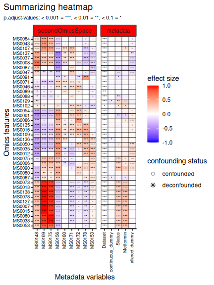

Figure 3: BuildHeatmap() output for mediation analysis data

```r
BuildHeatmap(
  example_outputMedi,
  keepMeta = colnames(metaMatMetformin),
  d_range = "full"
) +
  theme(strip.background = element_rect(fill = "red"))
```

# BuildHeatmap()

Minimal input consists only of an output object from the main `MetaDeconfound()` function. This will return in a ggplot2 heatmap with effect size as tile color and black asterisks or grey circles indicating significant and not confounded or confounded associations based on corrected p-values. The plot is clustered on both axes and features as well as meta-variables without any associations passing effect size and significance cutoffs (default: `q_cutoff = 0.1`, `d_cutoff = 0.01`) are removed (*Fig. 4*).

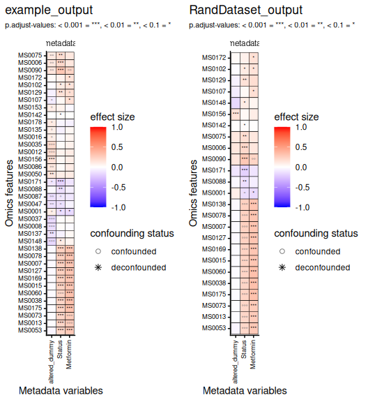

Figure 4: default output of the BuildHeatmap() function

```r
left <- BuildHeatmap(example_output)
right <- BuildHeatmap(RandDataset_output)
grid.arrange(left, right, ncol = 2)
```

## options

For both this default heatmap, as well as the alternative cuneiform plot (`cuneiform = TRUE`), a range of customizations are available. In *Fig. 5* meta-variables not passing the effect size and significance cutoffs are manually kept in the plot (`keepMeta`), and the shown range of effect sizes is set from -1 to +1 (`d_range = "full"`). For a full list of options, again, refer to the help page.

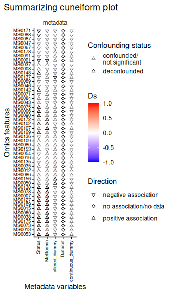

Figure 5: alternative cuneiform output of the BuildHeatmap() function

```r
BuildHeatmap(
  example_output,
  cuneiform = TRUE,
  keepMeta = colnames(metaMatMetformin),
  d_range = "full"
)
```

## ggplot2 options

The `BuildHeatmap()` function returns a ggplot2 object. This makes it possible to perform some easy alterations manually (*Fig. 6*).

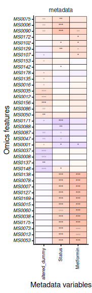

Figure 6: post-plotting ggplot2 alterations

```r
BuildHeatmap(example_output) +
  theme(
    legend.position = "none",
    axis.text.y = element_text(face = "italic"),
    plot.title = element_blank(),
    plot.subtitle = element_blank()
  )
```

## Grouping of metadata

An additional column “groupingVar” can be added to the long format `MetaDeconfound()` output, containing a set of group names. It can be used to separate the supplied metavariables into different groups. When running Mediation analysis, this column gets added automatically, so that features from `mediationMat` are clearly separated from the metavariables of `metaMat` in the `BuildHeatmap()` output. This splitting is based on `ggplot2::facet_grid()`, which allows for similar customizations through the `ggplot2::theme()` function as the main plot. The order of the groups in the resulting plot can be changed by editing the order of factor levels of the groupingVar column.

# BuildConfounderMap()

Minimal input consists only of an output object from the main `MetaDeconfound()` function. This will return in a list of ggplot2/ggrpah circos plots with one plot per input feature. All metavariables significantly associated to the respective feature are shown as circles with filling color and line thickness depicted as effect size and confounding status, respectively. The confounder-confounded relationship between the metavariables are shown as directional lines connecting them.

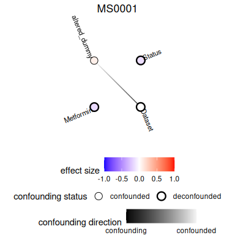

Figure 7: BuildConfounderMap() example plot

```r
plotObject <- BuildConfounderMap(example_output)
library(ggraph)
plotObject$MS0001
```

# importLongPrior()

The function `ImportLongPrior()` of the metadeconfoundR package allows for easy integration of a list of feature-metadata pairings into a new run of the main `Metadeconfound()` function.

These pairings must be supplied in the form of a long-format data.frame with the first column called “feature” containing names of omics features and the second column called “metaVariable” containing names of the respective associated metadata variable. When only these two columns are used as input for `ImportLongPrior()`, all given pairings are assumed to be significant.

Additional columns called “Qs” and “status”, as produced by metadeconfoundR can also be supplied.:

```r
print(example_output[101:105, ])
```

|  | feature | metaVariable | Ps | Qs | Ds | status |
| --- | --- | --- | --- | --- | --- | --- |
| 101 | MS0001 | Metformin | 0.0164764 | 0.0484600 | -0.1553640 | AD |
| 102 | MS0006 | Metformin | 0.0497210 | 0.1243026 | 0.1276733 | NS |
| 103 | MS0007 | Metformin | 0.0000008 | 0.0000059 | 0.3018286 | OK_sd |
| 104 | MS0008 | Metformin | 0.8044179 | 0.8379353 | -0.0161268 | NS |
| 105 | MS0012 | Metformin | 0.1202921 | 0.2227631 | 0.1010798 | NS |

Whenever the “status” column is part of the input, only feature–metadata pairings having a status other than “NS” are assumed to be significant.

To assure only features and metadata present in the current dataset are imported, the two input data.frames for the `Metadeconfound()` function, featureMat and metaMat, also need to be supplied to `ImportLongPrior()`. It is therefore important to have consistent naming of variables between datasets.

```r
minQValues <- ImportLongPrior(longPrior = example_output,
                                featureMat = reduced_feature,
                                metaMat = metaMatMetformin)
```

In any case, `ImportLongPrior()` will return a wide-format data.frame containing significance values for the supplied pairings. If a “Qs” column was part of the longPrior input, these multiple-testing corrected p-values will be used for the output. If no “Qs” was supplied, artificial “significant” values of -1 will be used to mark significant associations.

```r
print(minQValues[1:5, 1:5])
```

|  | Status | Dataset | Metformin | continuous_dummy | altered_dummy |
| --- | --- | --- | --- | --- | --- |
| MS0001 | 0.0103973 | 0 | 0.0484600 | NA | 0.0626943 |
| MS0006 | 0.0001147 | 0 | NA | NA | 0.0031886 |
| MS0007 | 0.0000016 | 0 | 0.0000059 | NA | NA |
| MS0008 | NA | 0 | NA | NA | 0.0008288 |
| MS0012 | NA | 0 | NA | NA | 0.0000325 |

This data.frame can now be used as the `minQValues` input parameter of `MetaDeconfound()`.

```r
example_output2 <- MetaDeconfound(featureMat = reduced_feature,
                                  metaMat = metaMatMetformin,
                                  minQValues = minQValues)
```

This way, all significant feature–metadata pairings in the `minQValues` data.frame will be treated as potential confounders in `MetaDeconfound()`.

Note that this example is only to demonstrate the general process of integrating prior knowledge into a `MetaDeconfound()` analysis. Using the output of a `MetaDeconfound()` run as `minQValues` input for a second run with the exact same features and metadata will not lead to any new insights since the set of QValues calculated by `MetaDeconfound()` and the set supplied using the `minQValues` parameter are identical in this case.

# GetPartialEfSizes()

Effect sizes returned by `MetaDeconfound()` are marginal effect sizes based on naive associations, and so do not take into account potential confounders. These marginal effect sizes can, therefore, be inflated and might not reflect the true effect size attributable exclusively to a metavariable. However, building large models including all available metavariables in order to compute partial effect sizes is neither feasible nor robust. Instead, we first run a normal `MetaDeconfound()` analysis. Subsequently, we supply the output from that run to `GetPartialEfSizes()`. This function calculates a partial effect size only for those metavariables labeled not as “NS” (not significant). Random and/or fixed effects used in the `MetaDeconfound()` analysis need to be supplied here again, alongside the original input data.frames.

For each feature, a full linear model with all identified metavariables as predictors is being built alongside a set of smaller models, each missing one of the metavariables. The partial R² is calculated as the difference in the coefficient of determination (“R²”) between the full model and one of the reduced models that excludes the respective metavariable.

These values as well as two different normalizations are reported in three new columns:

- “partial” is the raw partial R² (R²(full) - R²(reduced)) – it shows how much of the variance of a feature can only be explained by the respective metavariable.
- “partialRel” is calculated as ratio of partial R² to R² of the full model – it shows how much of the overall explainable variance of a feature is explained by the respective metavariable.
- “partialNorm” is calculated as ratio of partial R² to (1 - R² of the smaller model) – it shows how much of the not otherwise explainable variance of the feature can be explained by the respective metavariable, or how much of it’s explanatory potential a metavariable reaches.

Finally, the sign of the marginal effect size, i.e. the direction of the association, is transferred to the partial effect size, and the R² of the full model (“maxRsq”) is appended for each feature.

```r
ex_out_partial <- GetPartialEfSizes(
  featureMat = reduced_feature,
  metaMat = metaMatMetformin,
  metaDeconfOutput = RandDataset_output,
  randomVar = c("Dataset")
)
```

Output of `GetPartialEfSizes()` can be graphically summarized using `BuildHeatmap()`, but will show the partial effect sizes only if the `plotPartial` parameter is set. Note that the marginal effect sizes now get replaced by the specified partial R² values. The default effect size cutoff (`d_cutoff`) of 0.01 might need to be adjusted to be less strict.

[figure not shown]

Figure 8: BuildHeatmap() plotting of partial effect sizes calculated by GetPartialEfSizes()

```r
BuildHeatmap(ex_out_partial,
             plotPartial = "partial",
             d_cutoff = 0.0000001
            )
```

# Session Info

**R version 4.6.1 (2026-06-24)**

**Platform:** x86_64-pc-linux-gnu

**locale:** *LC_CTYPE=de_DE.UTF-8*, *LC_NUMERIC=C*, *LC_TIME=de_DE.UTF-8*, *LC_COLLATE=de_DE.UTF-8*, *LC_MONETARY=de_DE.UTF-8*, *LC_MESSAGES=de_DE.UTF-8*, *LC_PAPER=de_DE.UTF-8*, *LC_NAME=C*, *LC_ADDRESS=C*, *LC_TELEPHONE=C*, *LC_MEASUREMENT=de_DE.UTF-8* and *LC_IDENTIFICATION=C*

**attached base packages:** *stats*, *graphics*, *grDevices*, *utils*, *datasets*, *methods* and *base*

**other attached packages:** *ggraph(v.2.2.2)*, *kableExtra(v.1.4.0)*, *gridExtra(v.2.3)*, *ggplot2(v.4.0.3)*, *metadeconfoundR(v.1.0.6)* and *detectseparation(v.0.4.0)*

**loaded via a namespace (and not attached):** *tidyselect(v.1.2.1)*, *viridisLite(v.0.4.3)*, *dplyr(v.1.2.1)*, *farver(v.2.1.2)*, *viridis(v.0.6.5)*, *S7(v.0.2.2)*, *fastmap(v.1.2.0)*, *tweenr(v.2.0.3)*, *digest(v.0.6.39)*, *lifecycle(v.1.0.5)*, *magrittr(v.2.0.5)*, *compiler(v.4.6.1)*, *rlang(v.1.2.0)*, *sass(v.0.4.10)*, *tools(v.4.6.1)*, *igraph(v.2.3.2)*, *yaml(v.2.3.12)*, *knitr(v.1.51)*, *labeling(v.0.4.3)*, *graphlayouts(v.1.2.3)*, *xml2(v.1.5.2)*, *plyr(v.1.8.9)*, *RColorBrewer(v.1.1-3)*, *registry(v.0.5-1)*, *withr(v.3.0.2)*, *purrr(v.1.2.2)*, *numDeriv(v.2016.8-1.1)*, *grid(v.4.6.1)*, *polyclip(v.1.10-7)*, *colorspace(v.2.1-2)*, *scales(v.1.4.0)*, *iterators(v.1.0.14)*, *MASS(v.7.3-65)*, *cli(v.3.6.6)*, *rmarkdown(v.2.31)*, *reformulas(v.0.4.4)*, *generics(v.0.1.4)*, *otel(v.0.2.0)*, *rstudioapi(v.0.18.0)*, *reshape2(v.1.4.5)*, *minqa(v.1.2.8)*, *cachem(v.1.1.0)*, *ggforce(v.0.5.0)*, *pander(v.0.6.6)*, *stringr(v.1.6.0)*, *splines(v.4.6.1)*, *vctrs(v.0.7.3)*, *boot(v.1.3-32)*, *Matrix(v.1.7-5)*, *jsonlite(v.2.0.0)*, *slam(v.0.1-55)*, *ggrepel(v.0.9.8)*, *ROI.plugin.lpsolve(v.1.0-2)*, *systemfonts(v.1.3.2)*, *foreach(v.1.5.2)*, *tidyr(v.1.3.2)*, *jquerylib(v.0.1.4)*, *glue(v.1.8.1)*, *ROI(v.1.0-2)*, *nloptr(v.2.2.1)*, *codetools(v.0.2-20)*, *stringi(v.1.8.7)*, *gtable(v.0.3.6)*, *shape(v.1.4.6.1)*, *lmtest(v.0.9-40)*, *lme4(v.2.0-1)*, *tibble(v.3.3.1)*, *logger(v.0.4.2)*, *pillar(v.1.11.1)*, *htmltools(v.0.5.9)*, *circlize(v.0.4.18)*, *R6(v.2.6.1)*, *textshaping(v.1.0.5)*, *Rdpack(v.2.6.6)*, *tidygraph(v.1.3.1)*, *evaluate(v.1.0.5)*, *lpSolveAPI(v.5.5.2.0-17.15)*, *lattice(v.0.22-9)*, *rbibutils(v.2.4.1)*, *backports(v.1.5.1)*, *memoise(v.2.0.1)*, *bslib(v.0.11.0)*, *Rcpp(v.1.1.1-1.1)*, *svglite(v.2.2.2)*, *nlme(v.3.1-169)*, *checkmate(v.2.3.4)*, *xfun(v.0.58)*, *zoo(v.1.8-15)*, *pkgconfig(v.2.0.3)* and *GlobalOptions(v.0.1.4)*